# LAB 3: 선형추세가 있는 자료에서의 모형 적합

## 예제 1

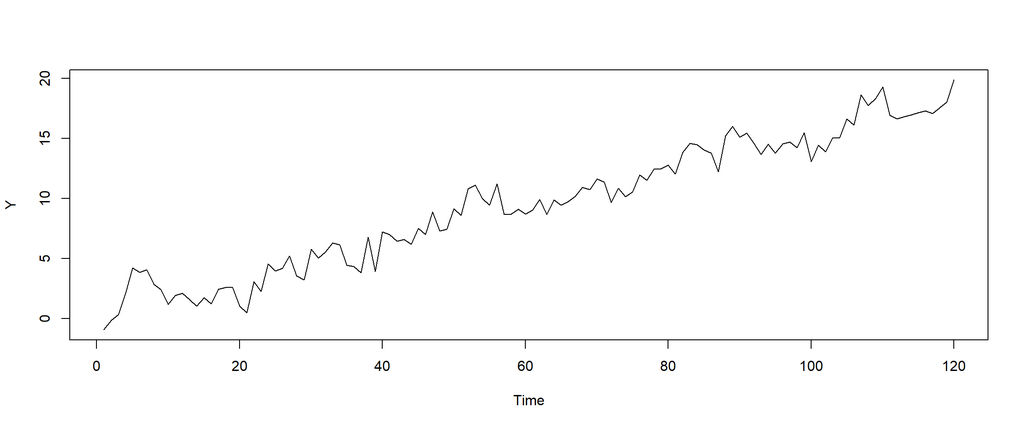

```r
> Y<-read.table("c://ex3-1.txt", header=T)[,1]
> ts.plot(Y)
```

선형추세에 대한 확신이 있는 경우 주어진 자료가

$$``선형추세 + 확률적 추세"인지\quad ``선형추세 + 정상과정"인지$$

확인하기 위하여 ADF검정을 수행.

```r
> library(aTSA)
> adf.test(Y)
```

```
Augmented Dickey-Fuller Test
alternative: stationary

Type 1: no drift no trend
     lag   ADF p.value
[1,]   0 0.799   0.872
[2,]   1 1.598   0.972
[3,]   2 1.652   0.976
[4,]   3 1.547   0.968
[5,]   4 2.025   0.990
Type 2: with drift no trend
     lag     ADF p.value
[1,]   0 -1.2044   0.625
[2,]   1 -0.8042   0.765
[3,]   2 -0.6978   0.803
[4,]   3 -0.4440   0.892
[5,]   4  0.0133   0.956
Type 3: with drift and trend
     lag   ADF p.value
[1,]   0 -6.21    0.01
[2,]   1 -4.35    0.01
[3,]   2 -4.37    0.01
[4,]   3 -4.91    0.01
[5,]   4 -4.50    0.01
----
Note: in fact, p.value = 0.01 means p.value <= 0.01
```

모형 3의 검정( 귀무가설: 이차곡선 + 확률적 추세, 대립가설: 선형추세 + 정상과정)에서 유의확률이 1% 미만으로 대립가설 선택. 즉, 주어진 자료는 “선형추세 + 정상과정”으로 볼 수 있고, 따라서 다음의 시간에 대한 회귀모형을 잠정모형으로 선택함.
$$Y_t = \alpha+\beta t +e_t$$
여기서 $\{e_t\}$ 는 어떤 정상 시계열. (이후 잔차분석을 통하여 오차항 에 대한 모형화)

### 시간에 대한 회귀분석

```r
> x<-1:length(Y)
> fit.lm<-lm(Y~x)
> summary(fit.lm)
```

```
Call:
lm(formula = Y ~ x)

Residuals:
    Min      1Q  Median      3Q     Max
-2.9892 -0.6844 -0.2297  0.7249  3.1843

Coefficients:
            Estimate Std. Error t value Pr(>|t|)
(Intercept) 0.270894   0.219081   1.237    0.219
x           0.152040   0.003143  48.381   <2e-16 ***
---
Signif. codes:  0 '***' 0.001 '**' 0.01 '*' 0.05 '.' 0.1 ' ' 1

Residual standard error: 1.192 on 118 degrees of freedom
Multiple R-squared:  0.952, Adjusted R-squared:  0.9516
F-statistic:  2341 on 1 and 118 DF,  p-value: < 2.2e-16
```

상수항이 없는 선형회귀모형으로 적합해도 될 듯함. 회귀모형 적합 후 바로 잔차분석 수행

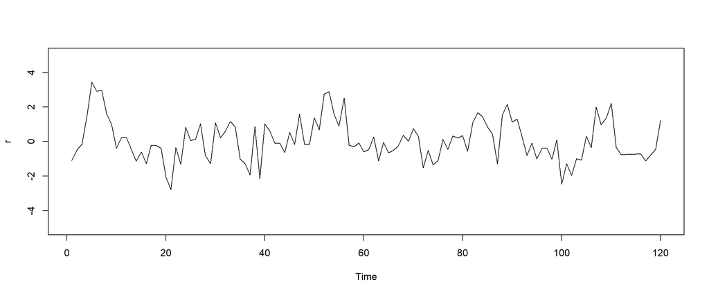

```r
> fit.lm<-lm(Y~0+x)
> r<-fit.lm$res
> ts.plot(r, ylim=c(-5,5))
```

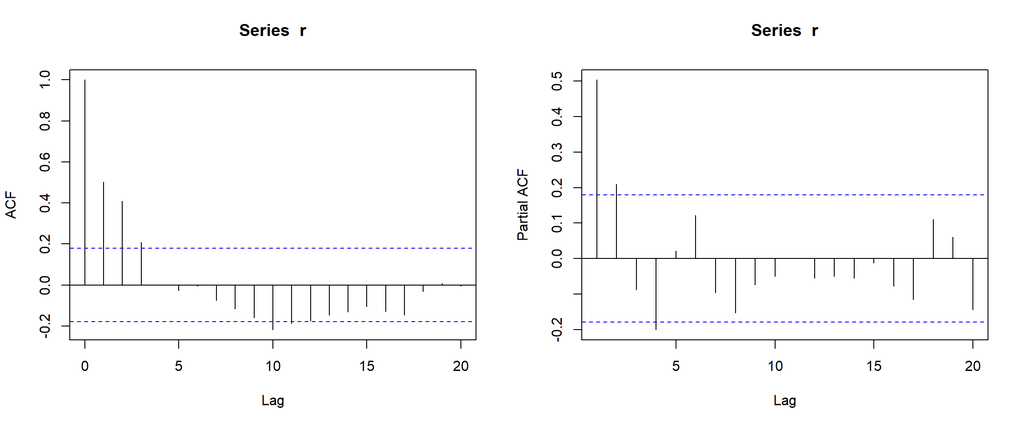

```r
> acf(r); pacf(r)
```

위에서 언급했던대로, 잔차$\{ \hat e_t\}$에 종속관계가 존재. 따라서 오차항 $\{e_t\}$는 white noise가 아닌 어떤 종속관계를 갖는 정상시계열로 판단됨.

잔차들 사이에 상관관계 존재 $\Longrightarrow$ (모형화할 수 있는)종속성 존재  
$\hspace{6.2cm}\Longrightarrow$ 잔차를 통하여 (관찰되지 않는) 오차항 $\{\epsilon_t\}$에 대한 모형화

### 오차항의 모형화

위 잔차의 SACF와 SPACF를 보면 오차항에 대하여 AR(2)모형 정도가 적당할 듯 함. 앞의 실습 2에서처럼 AIC, BIC를 기준으로 선택하여도 됨. 본 예제에서는 AR(2)로 모형화. 당연히 오차항의 기대값이 0으로 예상되나, 우선 기대값 모수 ($\mu$)를 포함하여 모형화함.
$$(1-\phi_1 B -\phi_2 B^2) (\color{blue} {e_t} -\mu) =\color{red}{\eta_t}$$
여기서 $\{\eta_t\}\ \sim \ W.N.\ (0,\sigma_\eta^2)$. ( 오차항의 오차항)

```r
> arima(r, order=c(2,0,0))
```

```
Call:
arima(x = r, order = c(2, 0, 0))

Coefficients:
         ar1     ar2  intercept
      0.4004  0.2070     0.0623
s.e.  0.0896  0.0896     0.2290

sigma^2 estimated as 1.003:  log likelihood = -170.67,  aic = 349.33
```

예상했던대로, $\mu=0$으로 간주해도 됨. 따라서 $\{\color{blue}{e_t}\}$를 $\mu$를 제외한 즉, 기대값이 0인 AR(2)로 모형화
$$(1-\phi_1 B -\phi_2 B^2)\color{blue} {e_t} =\color{red}{\eta_t}$$
위 모형에 대한 잔차분석 수행. 여기서 잔차는 $\{\color{red}{\eta_t}\}$에 대한 추정치.

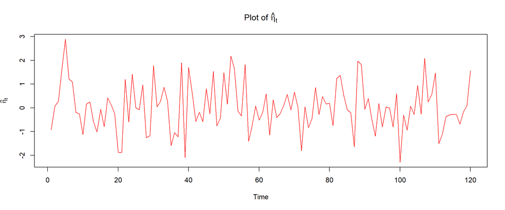

```r
> fit.e<-arima(r, order=c(2,0,0), include.mean=F)
> fit.e.res<-fit.e$res  #(빨간색)오차항에 대한 추정치
> plot(fit.e.res, main=expression(paste("Plot of ",  hat(eta)[t])),
+                 ylab=expression(hat(eta)[t]), col="red")
```

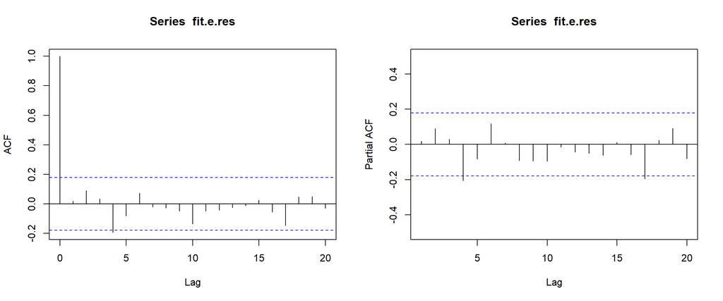

```r
> acf(fit.e.res); pacf(fit.e.res, ylim=c(-0.5,0.5))
```

잔차 $\{\color{\red}{\hat \eta_t}\}$가 white noise처럼 보이므로, 위 오차항에 대한 AR(2)모형을 최종모형으로 확정함. 따라서 원시계열자료에 대한 최종모형은 다음과 같음.

$$Y_t = \alpha+\beta t +e_t$$
여기서
$$(1-\phi_1 B -\phi_2 B^2)e_t =\eta_t$$
이고 $\{\eta_t\}\ \sim\ W.N(0,\sigma_\eta^2)$.

오차항에 대한 정보가 있을 경우(지금과 같이 AR(2)과정으로 모형화하는 경우)에는 이 정보를 이용하여 추정함.  
주로 사용되는 방법은 Generalized Least Square 추정법으로 선형회귀함수의 모수 $\alpha$와 $\beta$, 그리고 오차항의 모수 $\phi_1$과 $\phi_2$를 동시에 추정함.  
본 수업에서는 GLS를 사용하지 않고 LSE에 의하여 $\alpha$와 $\beta$를 추정하고 (즉, lm 함수로 추정) 이후 얻어진 잔차$\{\color{blue}{\hat e_t}\}$를 이용하여 $\phi_1$과 $\phi_2$ 추정함 (arima함수 이용). 각각의 모수 추정결과는 fit.lm과 fit.e에 포함되어 있음.

```r
> fit.lm
```

```
Call:
lm(formula = Y ~ 0 + x)

Coefficients:
     x
0.1554
```

```r
> fit.e
```

```
Call:
arima(x = r, order = c(2, 0, 0), include.mean = F)

Coefficients:
         ar1     ar2
      0.4010  0.2080
s.e.  0.0896  0.0896

sigma^2 estimated as 1.004:  log likelihood = -170.7,  aic = 347.41
```

### 예측

주어진 자료를 선형추세($\alpha + \beta t$)+ 정상과정($e_t$)로 모형화 하였으므로, 예측은 선형추세에 의한 예측부분과 정상과정에 의한 예측 부분의 합으로 생각할 수 있음.  
선형추세는 결정적 추세로서 확률적인 변동 없이 추정된 직선에서 계산된 값이 예측치가 됨.  
예측구간을 만들어내는 확률적 변동부분은 정상과정의 예측에서 얻어짐.

선형모형에서의 예측은 lm함수 사용 시 사용된 설명변수(지금 예제에서는 시간에 대한 설명변수로 x를 사용함, lm(Y~x))에 예측에 사용될 값을 입력한 새로운 data.frame이 필요. 그리고, data.frame 작성 시 lm에서 사용한 설명변수명을 주어야함.

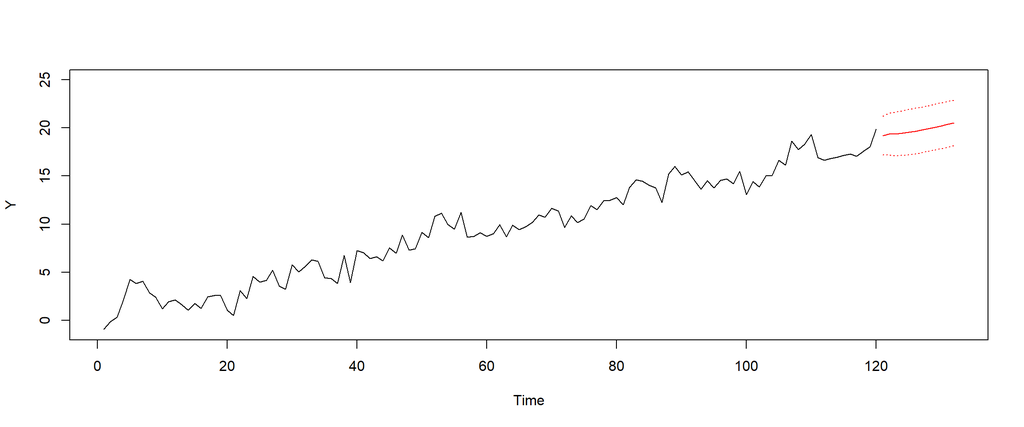

```r
> x.new<-data.frame(x=length(Y)+1:12) # x는 lm(Y~x)에서 사용된 설명변수 이름.
> Y.lm.fore<-predict(fit.lm, x.new)
> e.fore<-predict(fit.e, n.ahead=12)
>
> e.P<-e.fore$pred
> e.se<-e.fore$se
> e.L<-e.P-2*e.se
> e.U<-e.P+2*e.se
>
> Y.P<-Y.lm.fore+e.P
> Y.L<-Y.lm.fore+e.L
> Y.U<-Y.lm.fore+e.U
>
> ts.plot(Y, xlim=c(1,132), ylim=c(-1,25))
> lines(Y.P, col="red")
> lines(Y.L, col="red", lty=3)
> lines(Y.U, col="red", lty=3)
```

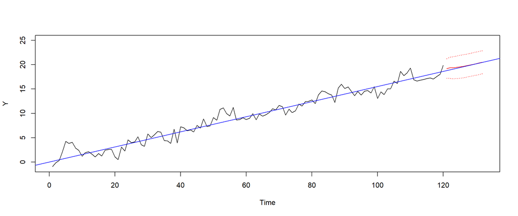

```r
> abline(fit.lm, col="blue")
```

## 예제 2

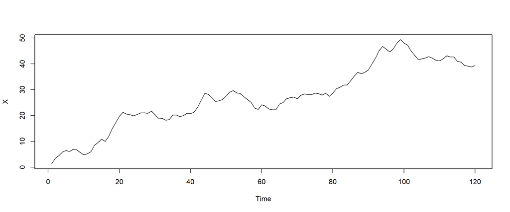

```r
> X<-read.table("c://ex3-2.txt", header=T)[,1]
> ts.plot(X)
```

선형추세에 대한 확신이 있는 경우 주어진 자료가

$$``선형추세 + 확률적 추세"인지\quad ``선형추세 + 정상과정"인지$$

확인하기 위하여 ADF검정을 수행.

```r
> adf.test(X)
```

```
Augmented Dickey-Fuller Test
alternative: stationary

Type 1: no drift no trend
     lag   ADF p.value
[1,]   0 1.728   0.978
[2,]   1 0.739   0.854
[3,]   2 0.874   0.893
[4,]   3 1.060   0.921
[5,]   4 0.892   0.898
Type 2: with drift no trend
     lag   ADF p.value
[1,]   0 -2.24   0.235
[2,]   1 -1.60   0.483
[3,]   2 -1.67   0.459
[4,]   3 -1.58   0.492
[5,]   4 -1.57   0.498
Type 3: with drift and trend
     lag   ADF p.value
[1,]   0 -1.47   0.793
[2,]   1 -2.48   0.373
[3,]   2 -2.27   0.459
[4,]   3 -1.90   0.614
[5,]   4 -2.08   0.541
----
Note: in fact, p.value = 0.01 means p.value <= 0.01
```

모든 모형에 대하여 유의확률이 큼. 특히, 모형 3(대립가설: 선형추세+정상과정)에서 유의확률이 크기 때문에 주어진 자료는 선형추세에 확률적추세가 더해진 형태로 판단됨. 따라서 차분 후 정상시계열, 특히 기대값이 0이 아닌 정상과정이될 것으로 예상됨.

### 차분된 자료 $\{\bigtriangledown X_t \}$에 대한 기대값이 0이 아닌 ARMA모형 식별

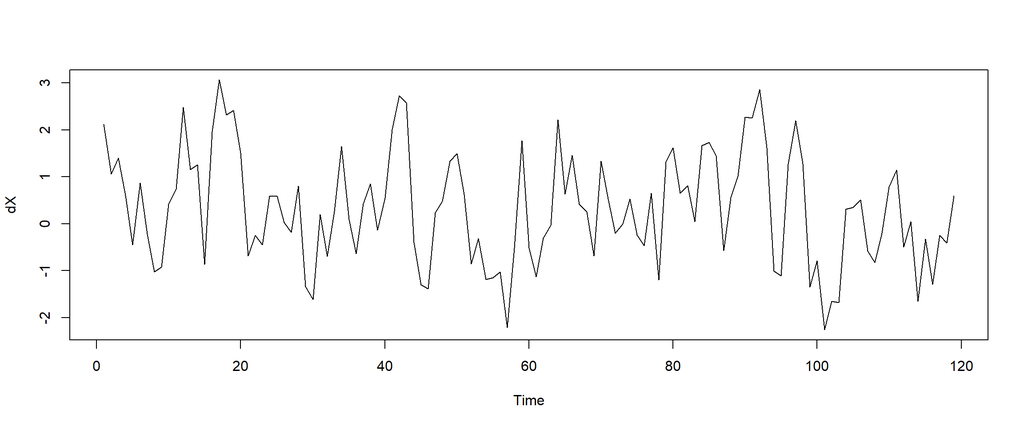

```r
> dX<-diff(X)
> ts.plot(dX)
```

기대값이 0이 아닌 정상시계열처럼 보임(?, 주관적으로 판단하기 힘듦. 하지만 선형 추세를 만들어내기 위해서는 0이 아닌 기대값을 포함시켜야함. 기대값이 0인 정상과정의 누적은 선형추세를 만들어내지 못 함.)

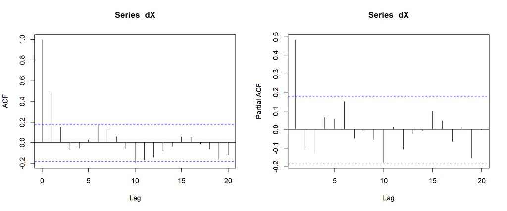

```r
> acf(dX); pacf(dX)
```

AR(1)정도로 모형화?

```r
> bic<-1000
> for(p in 0:3) for(q in 0:3){
+   bic.tmp<-BIC(arima(dX, order=c(p,0,q)))
+   if(bic.tmp<bic){
+     bic<-bic.tmp
+     cat("p=",p, "q=",q, " BIC=",bic ,"\n")
+   }
+ }
```

```
p= 0 q= 0  BIC= 389.1373
p= 0 q= 1  BIC= 366.0766
p= 0 q= 2  BIC= 363.4394
p= 1 q= 0  BIC= 361.4939
```

BIC기준으로 기대값이 0이 아닌 AR(1)모형을 잠정모형으로 선택하고 이에 대한 잔차분석 수행.

```r
> dX.fit<-arima(dX, order=c(1,0,0))
> dX.fit
```

```
Call:
arima(x = dX, order = c(1, 0, 0))

Coefficients:
         ar1  intercept
      0.4909     0.3356
s.e.  0.0801     0.1857

sigma^2 estimated as 1.08:  log likelihood = -173.58,  aic = 353.16
```

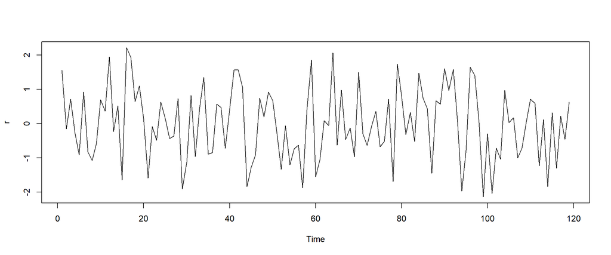

```r
> r<-dX.fit$res
> ts.plot(r)
```

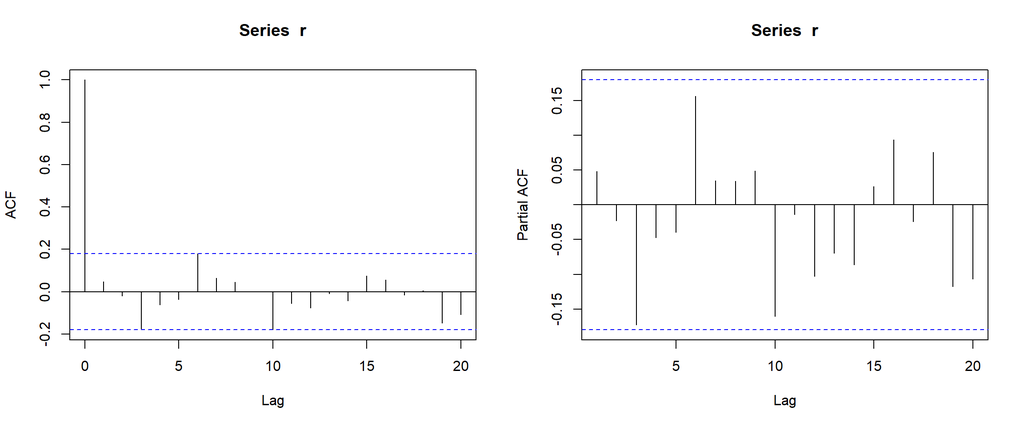

```r
> layout(t(1:2))
> acf(r); pacf(r)
```

$\mu=0$인지에 대한 검정결과는 귀무가설이 채택되나, 앞서 이야기 했듯이 본 자료는 선형추세에 대한 확신이 있기 때문에 $\mu$를 포함한 모형을 최종모형으로 선택함.
$$(1-\phi B)(\bigtriangledown X_t-\mu) = e_t$$
여기서 $\{e_t\}\ \sim\ W.N\ (0,\sigma_e^2)$.

### 예측

주어진 자료를 선형추세$(\mu t)$+ 확률적 추세$(X_1+\cdots+X_t)$로 모형화 하였으므로, 예측은 선형추세에 의한 예측부분과 확률적 추세에 대한 예측 부분의 합으로 생각할 수 있음. 여기서, 확률적 추세는 기대값이 0인 정상시계열의 합.

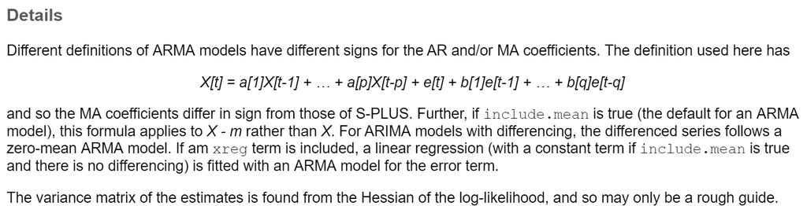

arima함수는 차분할 경우 기대값이 0인 ARMA모형으로 적합함. 이는 예측 시 선형추세가 없는 순수한 확률적추세(위에서 $X_1+\cdots+X_t$에 해당)에 대한 예측을 수행함을 의미함. 따라서, 선형추세에 의한 예측부분을 더해주어야함.

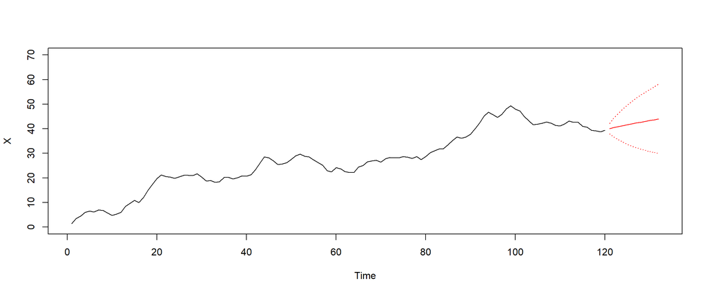

```r
> hat.mu<-arima(dX, order=c(1,0,0))$coef[2] # 차분된 자료의 기대값(mu)에 대한 추정치
>
> X.fit<-arima(X, order=c(1,1,0)) # 차분 후 zero-mean ARMA모형으로 적합
>
> X.fore<-predict(X.fit, n.ahead=12) #순수한 확률적 추세에 대한 예측 부분
>
> X.P<-X.fore$pred+hat.mu*(1:12) # hat.mu * (1:12)는 선형추세에 의한 예측 부분
> X.SE<-X.fore$se
> X.U<-X.P+2*X.SE
> X.L<-X.P-2*X.SE
>
> ts.plot(X,  xlim=c(1,132), ylim=c(0,70))
> lines(X.P,col="red")
> lines(X.L,col="red", lty=3)
> lines(X.U,col="red", lty=3)
```

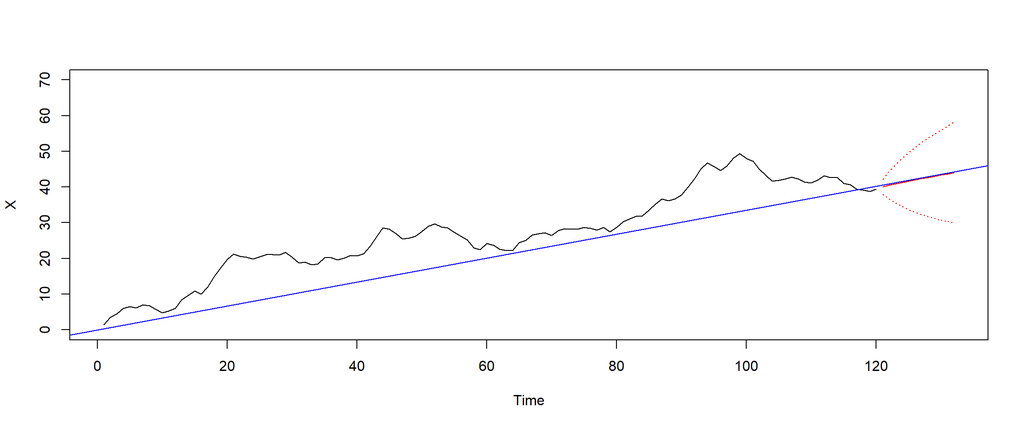

```r
> abline(0,hat.mu, col="blue")
```

예제 1에서의 예측결과와 비교해볼 것.